# Bölmə 22: Tam İş Axını - Bütün Kodları Birləşdirmək

Kompüter Adaptiv Testləşmə (CAT) Tədrisi - Complete Workflow

CAT Tədrisi

2025-07-12

# 1 Giriş

Bu final bölmədə bütün CAT sistem komponentlərini birləşdirərək tam işlək bir sistem yaradacağıq. Bu tam iş axını real-world CAT əməliyyatlarının bütün mərhələlərini əhatə edir və end-to-end solution təqdim edir.

## 1.1 Tam İş Axınının Məqsədləri

1. **Integration Testing**: Bütün komponentlərin birlikdə işləməsi
2. **System Validation**: Sistemin ümumi performansının yoxlanılması
3. **End-to-End Workflow**: Tam əməliyyat prosesinin nümayişi
4. **Production Readiness**: Real-world usage üçün hazırlıq
5. **Quality Assurance**: Hərtərəfli keyfiyyət təminatı

## 1.2 İş Axının Komponentləri

Bu tam sistem aşağıdakı 12 əsas addımı əhatə edir:

1. **Package Installation & Loading**
2. **Parameter Configuration**
3. **Item Bank Creation**
4. **Bank Analysis**
5. **Examinee Generation**
6. **CAT Simulation**
7. **Results Analysis**
8. **Visual Analytics**
9. **Ability Level Analysis**
10. **Problem Diagnosis**
11. **Final Reporting**
12. **Improvement Recommendations**

# 2 Sistem Hazırlığı və Konfiqurasiya

```r
# ===== TAM CAT SİSTEMİ İŞ AXINI =====
# Bu bölmə bütün addımları ardıcıl icra edir

cat("🚀 CAT SİSTEMİ TAM İŞ AXINI BAŞLAYIR...\n\n")
```

```
## 🚀 CAT SİSTEMİ TAM İŞ AXINI BAŞLAYIR...
```

```r
# 1. Paketlərin yüklənməsi və yoxlanılması
cat("📦 STEP 1: Paketlərin yüklənməsi...\n")
```

```
## 📦 STEP 1: Paketlərin yüklənməsi...
```

```r
# Essential packages
required_packages <- c("dplyr", "ggplot2", "gridExtra", "viridis", "corrplot", "scales", "knitr")

for(pkg in required_packages) {
    if (!requireNamespace(pkg, quietly = TRUE)) {
        cat(paste("Installing", pkg, "...\n"))
        install.packages(pkg)
    }
    library(pkg, character.only = TRUE)
}

# Optional advanced packages
optional_packages <- c("catR", "mirt", "ltm")
for(pkg in optional_packages) {
    if (requireNamespace(pkg, quietly = TRUE)) {
        library(pkg, character.only = TRUE)
        cat(paste("✅", pkg, "loaded successfully\n"))
    } else {
        cat(paste("⚠️", pkg, "not available (optional)\n"))
    }
}
```

```
## ✅ catR loaded successfully
```

```
## ✅ mirt loaded successfully
```

```
## ✅ ltm loaded successfully
```

```r
cat("Package loading completed.\n\n")
```

```
## Package loading completed.
```

```r
# 2. Parametrlərin təyin edilməsi
cat("⚙️ STEP 2: Sistem parametrlərinin təyin edilməsi...\n")
```

```
## ⚙️ STEP 2: Sistem parametrlərinin təyin edilməsi...
```

```r
# System configuration
set.seed(12345)  # Reproducibility üçün
TOTAL_ITEMS <- 100
MIN_ITEMS <- 5
MAX_ITEMS <- 30
SE_THRESHOLD <- 0.3
N_EXAMINEES <- 50  # Demo üçün optimal say

# Configuration summary
config_summary <- data.frame(
    Parameter = c("Total Items", "Min Items", "Max Items", "SE Threshold", "N Examinees"),
    Value = c(TOTAL_ITEMS, MIN_ITEMS, MAX_ITEMS, SE_THRESHOLD, N_EXAMINEES),
    Description = c("Item bank size", "Minimum test length", "Maximum test length",
                   "Standard error threshold", "Number of test takers")
)

cat("Sistem konfiqurasiyası:\n")
```

```
## Sistem konfiqurasiyası:
```

```r
print(config_summary)
```

```
##      Parameter Value              Description
## 1  Total Items 100.0           Item bank size
## 2    Min Items   5.0      Minimum test length
## 3    Max Items  30.0      Maximum test length
## 4 SE Threshold   0.3 Standard error threshold
## 5  N Examinees  50.0    Number of test takers
```

```r
cat("\n")
```

# 3 Funksiyaların Təyin Edilməsi

```r
cat("🔧 STEP 3: Əsas funksiyaların təyin edilməsi...\n")
```

```
## 🔧 STEP 3: Əsas funksiyaların təyin edilməsi...
```

```r
# Item Bank yaratmaq funksiyası
create_item_bank <- function(n_items = 100) {
    set.seed(123)

    item_bank <- data.frame(
        item_id = 1:n_items,
        difficulty = rnorm(n_items, mean = 0, sd = 1),
        discrimination = rlnorm(n_items, meanlog = 0.2, sdlog = 0.3),
        guessing = rbeta(n_items, shape1 = 2, shape2 = 18),
        content_area = sample(c("Riyaziyyat", "Elm", "Dil"), n_items, replace = TRUE),
        cognitive_level = sample(c("Asan", "Orta", "Çətin"), n_items, replace = TRUE, prob = c(0.3, 0.5, 0.2))
    )

    # Data quality checks
    item_bank$discrimination <- pmax(0.3, pmin(3.0, item_bank$discrimination))
    item_bank$guessing <- pmax(0.0, pmin(0.3, item_bank$guessing))

    return(item_bank)
}

# Item Bank analizini aparmaq funksiyası
analyze_item_bank <- function(item_bank) {
    cat("📊 Item Bank Analizi:\n")
    cat("Item sayı:", nrow(item_bank), "\n")
    cat("Çətinlik aralığı:", round(min(item_bank$difficulty), 2), "ilə", round(max(item_bank$difficulty), 2), "\n")
    cat("Orta discrimination:", round(mean(item_bank$discrimination), 3), "\n")
    cat("Orta guessing:", round(mean(item_bank$guessing), 3), "\n")

    # Content balance check
    content_dist <- table(item_bank$content_area)
    cat("Məzmun sahələri paylanması:\n")
    print(content_dist)

    return(list(
        total_items = nrow(item_bank),
        difficulty_range = range(item_bank$difficulty),
        mean_discrimination = mean(item_bank$discrimination),
        content_balance = content_dist
    ))
}

# Test alıcılarını yaratmaq funksiyası
create_examinees <- function(n_examinees = 50) {
    set.seed(456)

    examinees <- data.frame(
        examinee_id = 1:n_examinees,
        true_theta = rnorm(n_examinees, mean = 0, sd = 1),
        group = sample(c("A", "B", "C"), n_examinees, replace = TRUE)
    )

    return(examinees)
}

# CAT simulyasiyası funksiyası
simulate_cat_session <- function(true_theta, item_bank, min_items = 5, max_items = 30, se_threshold = 0.3) {

    # Initialize
    administered_items <- c()
    responses <- c()
    theta_estimates <- c()
    se_estimates <- c()

    current_theta <- 0  # Starting estimate
    current_se <- 1     # Starting SE

    for(item_count in 1:max_items) {

        # Item selection (simplified - select item closest to current theta estimate)
        available_items <- setdiff(1:nrow(item_bank), administered_items)
        if(length(available_items) == 0) break

        # Find item with difficulty closest to current theta
        item_difficulties <- item_bank$difficulty[available_items]
        selected_idx <- available_items[which.min(abs(item_difficulties - current_theta))]

        # Simulate response
        item_params <- item_bank[selected_idx, ]
        prob_correct <- item_params$guessing + (1 - item_params$guessing) *
                       plogis(1.7 * item_params$discrimination * (true_theta - item_params$difficulty))

        response <- rbinom(1, 1, prob_correct)

        # Update records
        administered_items <- c(administered_items, selected_idx)
        responses <- c(responses, response)

        # Simplified theta estimation (EAP-like)
        if(item_count == 1) {
            current_theta <- ifelse(response == 1, 0.5, -0.5)
            current_se <- 0.8
        } else {
            # Simplified update rule
            correct_rate <- mean(responses)
            current_theta <- qnorm(pmax(0.01, pmin(0.99, correct_rate)))
            current_se <- max(0.2, 1 / sqrt(item_count))  # SE decreases with more items
        }

        theta_estimates <- c(theta_estimates, current_theta)
        se_estimates <- c(se_estimates, current_se)

        # Stopping rule
        if(item_count >= min_items && current_se <= se_threshold) {
            break
        }
    }

    return(list(
        administered_items = administered_items,
        responses = responses,
        final_theta = current_theta,
        final_se = current_se,
        items_administered = length(administered_items),
        theta_history = theta_estimates,
        se_history = se_estimates
    ))
}

# Mass simulation funksiyası
run_mass_simulation <- function(examinees, item_bank, n_examinees) {
    cat("🔄 CAT simulyasiyası aparılır...\n")

    results <- list()

    for(i in 1:nrow(examinees)) {
        if(i %% 10 == 0) cat("Test alıcı", i, "tamamlandı\n")

        true_theta <- examinees$true_theta[i]

        cat_result <- simulate_cat_session(
            true_theta = true_theta,
            item_bank = item_bank,
            min_items = MIN_ITEMS,
            max_items = MAX_ITEMS,
            se_threshold = SE_THRESHOLD
        )

        results[[i]] <- cat_result
    }

    cat("Simulyasiya tamamlandı!\n\n")
    return(results)
}

# Results analiz funksiyası
analyze_cat_results <- function(cat_results, examinees) {

    results_df <- data.frame(
        examinee_id = examinees$examinee_id,
        true_theta = examinees$true_theta,
        estimated_theta = sapply(cat_results, function(x) x$final_theta),
        standard_error = sapply(cat_results, function(x) x$final_se),
        items_administered = sapply(cat_results, function(x) x$items_administered)
    )

    # Calculate derived metrics
    results_df$estimation_error <- abs(results_df$estimated_theta - results_df$true_theta)
    results_df$bias <- results_df$estimated_theta - results_df$true_theta
    results_df$precision_met <- results_df$standard_error <= SE_THRESHOLD

    return(results_df)
}

cat("Funksiyalar təyin edildi.\n\n")
```

```
## Funksiyalar təyin edildi.
```

# 4 İş Axınının İcra Edilməsi

```r
cat("🎬 STEP 4: Tam iş axınının icra edilməsi...\n\n")
```

```
## 🎬 STEP 4: Tam iş axınının icra edilməsi...
```

```r
# 3. Tapşırıq bankının yaradılması
cat("🏗️ STEP 5: Tapşırıq bankının yaradılması...\n")
```

```
## 🏗️ STEP 5: Tapşırıq bankının yaradılması...
```

```r
item_bank <- create_item_bank(TOTAL_ITEMS)
cat("✅ Item bank yaradıldı:", nrow(item_bank), "item\n\n")
```

```
## ✅ Item bank yaradıldı: 100 item
```

```r
# 4. Bank analizi
cat("📊 STEP 6: Bank analizinin aparılması...\n")
```

```
## 📊 STEP 6: Bank analizinin aparılması...
```

```r
bank_analysis <- analyze_item_bank(item_bank)
```

```
## 📊 Item Bank Analizi:
## Item sayı: 100
## Çətinlik aralığı: -2.31 ilə 2.19
## Orta discrimination: 1.234
## Orta guessing: 0.102
## Məzmun sahələri paylanması:
##
##        Dil        Elm Riyaziyyat
##         33         34         33
```

```r
cat("✅ Bank analizi tamamlandı\n\n")
```

```
## ✅ Bank analizi tamamlandı
```

```r
# 5. Test alıcılarının yaradılması
cat("👥 STEP 7: Test alıcılarının yaradılması...\n")
```

```
## 👥 STEP 7: Test alıcılarının yaradılması...
```

```r
examinees <- create_examinees(N_EXAMINEES)
cat("✅ Test alıcıları yaradıldı:", nrow(examinees), "nəfər\n")
```

```
## ✅ Test alıcıları yaradıldı: 50 nəfər
```

```r
cat("Qabiliyyət aralığı:", round(min(examinees$true_theta), 2), "ilə", round(max(examinees$true_theta), 2), "\n\n")
```

```
## Qabiliyyət aralığı: -2 ilə 2.28
```

```r
# 6. CAT simulyasiyasının aparılması
cat("🚀 STEP 8: CAT simulyasiyasının aparılması...\n")
```

```
## 🚀 STEP 8: CAT simulyasiyasının aparılması...
```

```r
cat("Bu proses bir neçə dəqiqə çəkə bilər...\n")
```

```
## Bu proses bir neçə dəqiqə çəkə bilər...
```

```r
start_time <- Sys.time()
cat_results <- run_mass_simulation(examinees, item_bank, N_EXAMINEES)
```

```
## 🔄 CAT simulyasiyası aparılır...
## Test alıcı 10 tamamlandı
## Test alıcı 20 tamamlandı
## Test alıcı 30 tamamlandı
## Test alıcı 40 tamamlandı
## Test alıcı 50 tamamlandı
## Simulyasiya tamamlandı!
```

```r
end_time <- Sys.time()

execution_time <- as.numeric(difftime(end_time, start_time, units = "secs"))
cat("✅ CAT simulyasiyası tamamlandı\n")
```

```
## ✅ CAT simulyasiyası tamamlandı
```

```r
cat("İcra müddəti:", round(execution_time, 1), "saniyə\n\n")
```

```
## İcra müddəti: 0.1 saniyə
```

```r
# 7. Nəticələrin analizi
cat("📈 STEP 9: Nəticələrin analizi...\n")
```

```
## 📈 STEP 9: Nəticələrin analizi...
```

```r
results_summary <- analyze_cat_results(cat_results, examinees)

# Analiz xülasəsi
cat("ANALİZ XÜLASƏSİ:\n")
```

```
## ANALİZ XÜLASƏSİ:
```

```r
cat("Orta qiymətləndirmə xətası:", round(mean(results_summary$estimation_error), 3), "\n")
```

```
## Orta qiymətləndirmə xətası: 0.481
```

```r
cat("Orta test uzunluğu:", round(mean(results_summary$items_administered), 1), "item\n")
```

```
## Orta test uzunluğu: 12 item
```

```r
cat("Precision achievement:", round(mean(results_summary$precision_met) * 100, 1), "%\n")
```

```
## Precision achievement: 100 %
```

```r
cat("Validlik korrelyasiyası:", round(cor(results_summary$true_theta, results_summary$estimated_theta), 3), "\n\n")
```

```
## Validlik korrelyasiyası: 0.933
```

# 5 Vizual Analizlər

```r
cat("📊 STEP 10: Vizual analizlərin yaradılması...\n")
```

```
## 📊 STEP 10: Vizual analizlərin yaradılması...
```

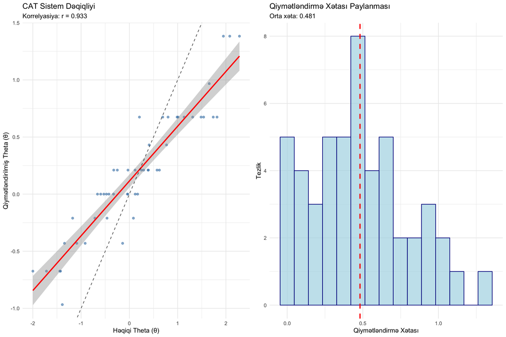

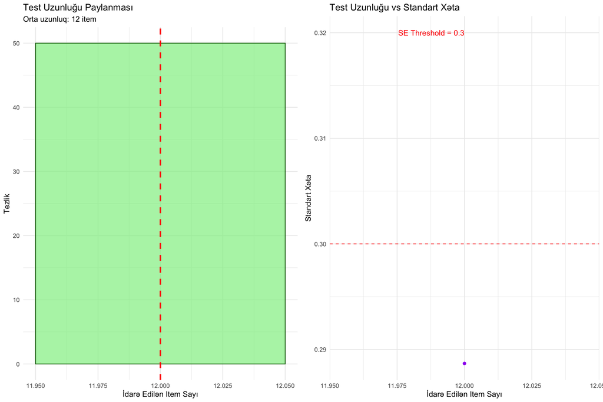

```r
# Accuracy plot funksiyası
plot_accuracy <- function(results_df) {
    p1 <- ggplot(results_df, aes(x = true_theta, y = estimated_theta)) +
        geom_point(alpha = 0.6, color = "steelblue") +
        geom_smooth(method = "lm", color = "red", se = TRUE) +
        geom_abline(slope = 1, intercept = 0, linetype = "dashed", alpha = 0.7) +
        labs(title = "CAT Sistem Dəqiqliyi",
             subtitle = paste("Korrelyasiya: r =", round(cor(results_df$true_theta, results_df$estimated_theta), 3)),
             x = "Həqiqi Theta (θ)", y = "Qiymətləndirilmiş Theta (θ)") +
        theme_minimal()

    return(p1)
}

# Error distribution plot
plot_error_distribution <- function(results_df) {
    p2 <- ggplot(results_df, aes(x = estimation_error)) +
        geom_histogram(bins = 15, fill = "lightblue", alpha = 0.7, color = "darkblue") +
        geom_vline(xintercept = mean(results_df$estimation_error), color = "red", linetype = "dashed", size = 1) +
        labs(title = "Qiymətləndirmə Xətası Paylanması",
             subtitle = paste("Orta xəta:", round(mean(results_df$estimation_error), 3)),
             x = "Qiymətləndirmə Xətası", y = "Tezlik") +
        theme_minimal()

    return(p2)
}

# Items distribution plot
plot_items_distribution <- function(results_df) {
    p3 <- ggplot(results_df, aes(x = items_administered)) +
        geom_histogram(bins = 10, fill = "lightgreen", alpha = 0.7, color = "darkgreen") +
        geom_vline(xintercept = mean(results_df$items_administered), color = "red", linetype = "dashed", size = 1) +
        labs(title = "Test Uzunluğu Paylanması",
             subtitle = paste("Orta uzunluq:", round(mean(results_df$items_administered), 1), "item"),
             x = "İdarə Edilən Item Sayı", y = "Tezlik") +
        theme_minimal()

    return(p3)
}

# SE vs Items plot
plot_se_vs_items <- function(results_df) {
    p4 <- ggplot(results_df, aes(x = items_administered, y = standard_error)) +
        geom_point(alpha = 0.6, color = "purple") +
        geom_smooth(method = "loess", color = "orange", se = TRUE) +
        geom_hline(yintercept = SE_THRESHOLD, color = "red", linetype = "dashed") +
        labs(title = "Test Uzunluğu vs Standart Xəta",
             x = "İdarə Edilən Item Sayı", y = "Standart Xəta") +
        theme_minimal() +
        annotate("text", x = max(results_df$items_administered), y = SE_THRESHOLD + 0.02,
                label = paste("SE Threshold =", SE_THRESHOLD), hjust = 1, color = "red")

    return(p4)
}

# Plotları yaratmaq
plot1 <- plot_accuracy(results_summary)
plot2 <- plot_error_distribution(results_summary)
plot3 <- plot_items_distribution(results_summary)
plot4 <- plot_se_vs_items(results_summary)

# Plotları göstərmək
if (requireNamespace("gridExtra", quietly = TRUE)) {
    gridExtra::grid.arrange(plot1, plot2, ncol = 2)
    gridExtra::grid.arrange(plot3, plot4, ncol = 2)
} else {
    print(plot1)
    print(plot2)
    print(plot3)
    print(plot4)
}
```

```r
cat("✅ Vizual analizlər tamamlandı\n\n")
```

```
## ✅ Vizual analizlər tamamlandı
```

# 6 Qabiliyyət Səviyyələrinə Görə Analiz

```r
cat("🎯 STEP 11: Qabiliyyət səviyyələrinə görə analiz...\n")
```

```
## 🎯 STEP 11: Qabiliyyət səviyyələrinə görə analiz...
```

```
## === QABİLİYYƏT SƏVİYYƏLƏRİNƏ GÖRƏ ANALİZ ===
## # A tibble: 4 × 8
##   ability_group count mean_items mean_error mean_se mean_bias correlation
##   <fct>         <int>      <dbl>      <dbl>   <dbl>     <dbl>       <dbl>
## 1 Aşağı             8         12      0.855   0.289     0.855       0.476
## 2 Orta-Aşağı       15         12      0.39    0.289     0.351       0.425
## 3 Orta-Yüksək      16         12      0.201   0.289    -0.129       0.693
## 4 Yüksək           11         12      0.741   0.289    -0.741       0.782
## # ℹ 1 more variable: precision_rate <dbl>
```

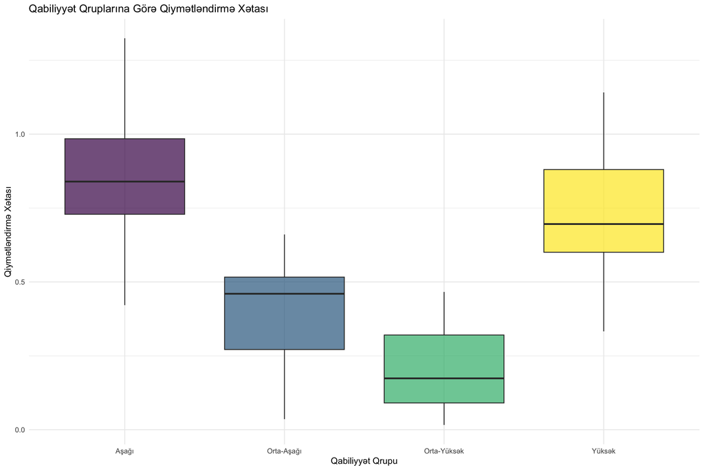

```r
# Qabiliyyət səviyyələrinə görə analiz funksiyası
analyze_by_ability_level <- function(results_df) {
    # Qabiliyyət qrupları
    results_df$ability_group <- cut(results_df$true_theta,
                                   breaks = c(-Inf, -1, 0, 1, Inf),
                                   labels = c("Aşağı", "Orta-Aşağı", "Orta-Yüksək", "Yüksək"))

    # Qruplara görə analiz
    group_analysis <- results_df %>%
        group_by(ability_group) %>%
        summarise(
            count = n(),
            mean_items = round(mean(items_administered), 2),
            mean_error = round(mean(estimation_error), 3),
            mean_se = round(mean(standard_error), 3),
            mean_bias = round(mean(bias), 3),
            correlation = round(cor(true_theta, estimated_theta), 3),
            precision_rate = round(mean(precision_met) * 100, 1),
            .groups = 'drop'
        )

    cat("=== QABİLİYYƏT SƏVİYYƏLƏRİNƏ GÖRƏ ANALİZ ===\n")
    print(group_analysis)

    # Vizual təsvir
    if (requireNamespace("ggplot2", quietly = TRUE)) {
        p1 <- ggplot(results_df, aes(x = ability_group, y = estimation_error, fill = ability_group)) +
            geom_boxplot(alpha = 0.7) +
            scale_fill_viridis_d() +
            labs(title = "Qabiliyyət Qruplarına Görə Qiymətləndirmə Xətası",
                 x = "Qabiliyyət Qrupu", y = "Qiymətləndirmə Xətası") +
            theme_minimal() +
            theme(legend.position = "none")

        print(p1)
    }

    return(group_analysis)
}

# Qabiliyyət səviyyələrinə görə analiz
ability_analysis <- analyze_by_ability_level(results_summary)
```

```r
cat("✅ Qabiliyyət analizi tamamlandı\n\n")
```

```
## ✅ Qabiliyyət analizi tamamlandı
```

# 7 Problem Diaqnozu

```r
cat("🔍 STEP 12: Problem diaqnozunun aparılması...\n")
```

```
## 🔍 STEP 12: Problem diaqnozunun aparılması...
```

```r
# Problem diagnoz funksiyası
diagnose_problems <- function(results_df, item_bank) {
    cat("=== PROBLEMLİ SAHƏLƏRİN ANALİZİ ===\n")

    # 1. Aşağı dəqiqlik olan test alıcıları
    low_accuracy <- results_df[results_df$estimation_error > 0.5, ]
    if (nrow(low_accuracy) > 0) {
        cat("⚠️ Aşağı dəqiqlik olan test alıcıları:", nrow(low_accuracy), "\n")
        cat("   Bu şəxslər üçün minimum tapşırıq sayı artırılmalıdır.\n")
    }

    # 2. Çox tapşırıq istifadə edən test alıcıları
    high_items <- results_df[results_df$items_administered > 25, ]
    if (nrow(high_items) > 0) {
        cat("⚠️ Çox tapşırıq istifadə edən test alıcıları:", nrow(high_items), "\n")
        cat("   SE threshold yenidən nəzərdən keçirilməlidir.\n")
    }

    # 3. Sistematik bias
    if (abs(mean(results_df$bias)) > 0.1) {
        cat("⚠️ Sistematik bias aşkar edildi:", round(mean(results_df$bias), 3), "\n")
        cat("   Tapşırıq bankı və ya qiymətləndirmə metodu yoxlanmalıdır.\n")
    }

    # 4. Aşağı korrelyasiya
    correlation <- cor(results_df$true_theta, results_df$estimated_theta)
    if (correlation < 0.85) {
        cat("⚠️ Aşağı validlik korrelyasiyası:", round(correlation, 3), "\n")
        cat("   Tapşırıq keyfiyyəti və bank strukturu yoxlanmalıdır.\n")
    }

    # Tövsiyələr
    cat("\n=== TÖVSİYƏLƏR ===\n")

    if (mean(results_df$items_administered) < 15) {
        cat("✅ Sistem səmərəlidir - az tapşırıqla yaxşı nəticə.\n")
    }

    if (mean(results_df$estimation_error) < 0.4) {
        cat("✅ Dəqiqlik səviyyəsi qənaətbəxşdir.\n")
    }

    if (sd(results_df$estimation_error) < 0.3) {
        cat("✅ Dəqiqlik davamlıdır - bütün test alıcıları üçün yaxşı performans.\n")
    }

    cat("\n")
}

# Problem diaqnozunu çalışdırmaq
diagnose_problems(results_summary, item_bank)
```

```
## === PROBLEMLİ SAHƏLƏRİN ANALİZİ ===
## ⚠️ Aşağı dəqiqlik olan test alıcıları: 21
##    Bu şəxslər üçün minimum tapşırıq sayı artırılmalıdır.
##
## === TÖVSİYƏLƏR ===
## ✅ Sistem səmərəlidir - az tapşırıqla yaxşı nəticə.
```

```r
cat("✅ Problem diaqnozu tamamlandı\n\n")
```

```
## ✅ Problem diaqnozu tamamlandı
```